# Demo #6 - ABM project

2021-03-25

## Background for ABM project

**Goal:**

1. Replace the previous ABM i.e. Annual Bibliometric Monitoring / Årlig Bibliometrisk Uppföljning at KTH
2. Further develop the ABM based on input from this group

**Summary:**

Our [previous demo meeting](https://KTH-Library.github.io/demo-5) was held 2020-11-10. After christmas vacations we have worked on Sprints **24 to 31** (current).

**Netiquette:**

Please use Zoom, raise hand for questions or write in the chat, mute if not speaking, and think about questions for the Q&A session at the end.

## Agenda

- Recap from previous meetings - What **feedback** has been given so far in the project?
- Progress - What is **new** since last meeting?
- A **demo** presenting new work (based on 2020 data update)

> *Short break, with possibility to look at applications*
- Some interpretations and **comparisons** between data sources and models for ABM
- Update about **other efforts** (data integration, APIs etc)
- Your **questions and feedback**

## Demo group feedback

You have provided many suggestions about steps forward, beyond the “old” ABM application. Here is a rough attempt to summarize input since the project start into some themes:

- One theme has been **Scopus data** and its inclusion in ABM
- Another theme has been about presenting **results at division level** in an author-based variant of ABM that focuses more a “current view”
- **User Experience improvements** with closer alignment with KTH Style on the web
- Addition of **Open Access data/reports** including Altmetric integration

## Feedback Recap (continued …)

- Data integration against **other (non-WoS) sources**
  - Requests regarding Microsoft Academic, Semantic Scholar, Google Scholar etc and ORCID matching (added in Kontarion and DiVA package)
  - Coverage for conference proceedings in CS (partially addressed by Scopus)
  - Custom “divisions” with arbitrary researchers (a POC experiment made in separate app)
- Another theme has been ideas about new ways to interactively **access, view and explore** the ÅBU data
  - Data Quality and Curation aspects, for example for usage of HR / researcher data from KTH
  - Raw data access, APIs (mostly non-public APIs due to usage rights for WoS and Scopus data)

## Progress - What is new during Q1?

- Data update with updated data for 2013-2019 including RAE data delivery
- Data integration for Scopus data added
- Addition of author-based report with output at divisional level based on KTH HR-data
- Brief interpretation and comparison of results based on new data for 2020
- New Open Access report included - what does it say?
- Other related efforts (non-app-specific)

## Demo

- **ABM updated with data for 2013-2019**(https://abm.sys.kth.se/public/)
- **Scopus** in ABM
- **Author-based ABM** (https://bibliometrics.lib.kth.se/beta/authorbased)
- Research-oriented divisions based on HR/UG-data
- New OA report - link added in application:  
  (https://kth-library.github.io/abm/OARapport.pdf)

## Interpretation of **results**

- How does results based on Scopus and WoS differ?
- Comparison organizational-based ABM vs author-based
- What patterns can we see? Trends over time?
- Highlights and deviations

## WoS vs Scopus

- Additional help in interpretation, e.g. corroborating trends
- Differences in coverage, depends on subject field and publication profile
- Field-normalization done against different standardization groups
  - what does different indicator values mean?
  - alternative ways to field-normalization
  - can interact with subject profile, especially for narrower selections (e.g. divisions)
- Other benchmark needed(?)

## WoS vs Scopus, citations

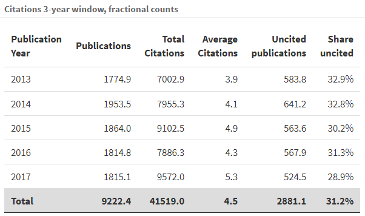

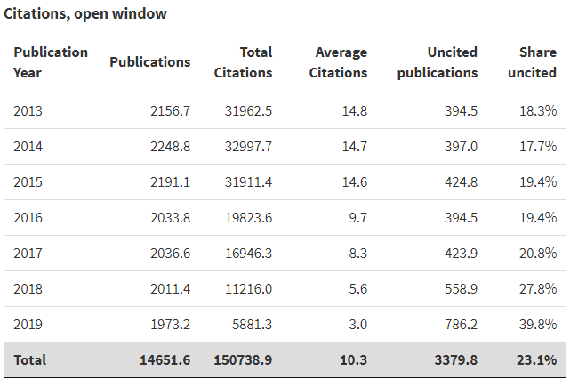

- WoS is 3 year citation window, Scopus is open citation window
- Conference papers included in both
- Neither include self-citations

## WoS vs Scopus, normalized citations

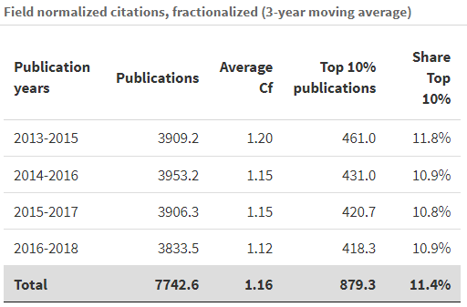

[figure not shown]

- Conference papers included from Scopus (FWCI), not from WoS (Cf)
- Papers are compared to other papers in the same data source
- Cf is normalized by KTHB on Web of Science subject categories
- FWCI is normalized by Scopus

## WoS vs Scopus, journal impact

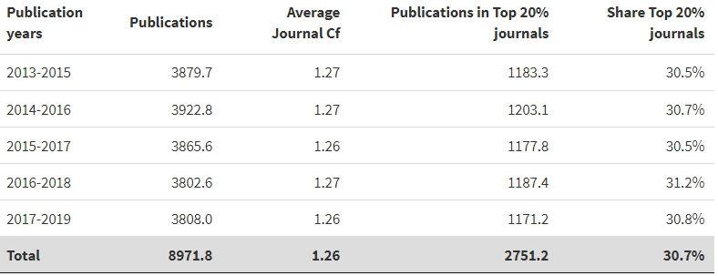

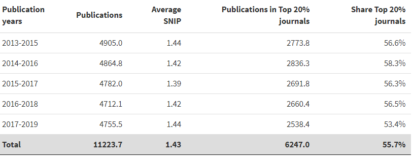

- Conference papers included from Scopus, but many have no SNIP
- In general, journal indicators from Scopus much higher than those based on WoS
- KTH average relatively high, based on both data sources

## Regular ABM vs author-based version

- Different scope of applications
  - Regular ABM: selection based on links between units and publications (address affiliations)
  - author-based: selection based on current staff and all their KTH publications
- Probably biased selection of staff categories, due to levels of turnover
- In general, lower volumes in staff-based version
- Citation indicators with varying effects between selections

## Regular ABM vs staff-based, publications

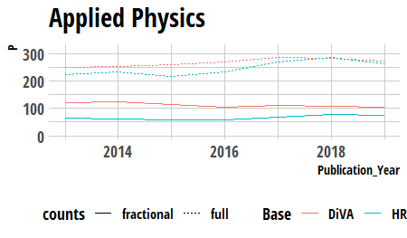

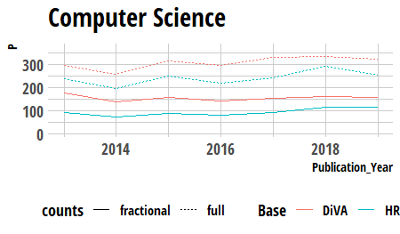

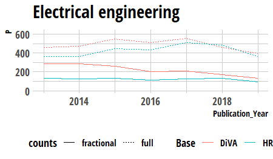

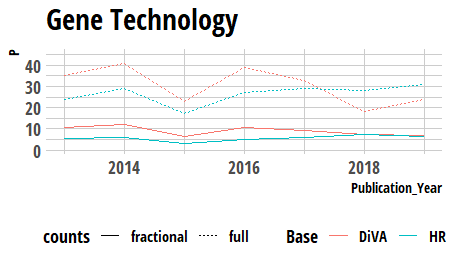

## Regular ABM vs staff-based, Cf

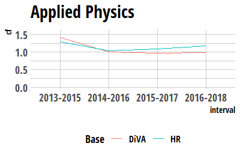

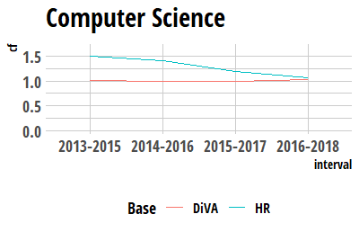

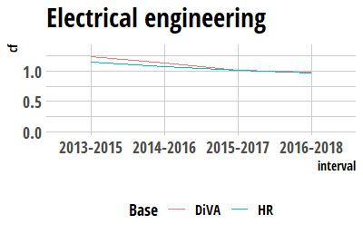

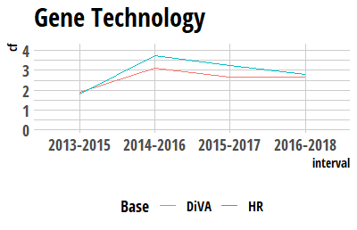

## Going forward

## Going forward

- Focusing on additions to collaboration data
- Suggestion:
  - Add coarse overview of collaborating organizations (as table) to ABM
  - Further collaboration data presented through separate application
- Working more in practice with new HR-data resource

## Other efforts

- Efforts made are available at [KTH-Library@GitHub](https://github.com/kth-library), including [`bibliomatrix`](https://github.com/kth-library/bibliomatrix) now with an API and Static site generation tool used for deploying author-based ABM
- New python tools [`bibutils`](https://github.com/KTH-Library/bibutils) for Data Quality and Curation
- A new R package [`diva`](https://gita.sys.kth.se/kthb/diva) with Data Quality/Curation tooling for the KTH corpus (publications and authors)
- A new R package [`cordis`](https://github.com/KTH-Library/cordis) provides data access to EU data for research projects, including a new data-only repository [’cordis-data`](https://github.com/KTH-Library/cordis-data), piggybacking on GitHub, using it for storing releases of versioned data publicly.
- Integration with HR data (extract to SFTP site) flowing into modern object storage (using https://min.io/).

## Questions and feedback

## Questions and Answers

Please provide your input!

- Do you think the what was presented in the demonstration meets your needs for **Scopus data** in ABM?
- What advantages and disadvantages do you see with introducing these **additional dimensions** into ABM (more data sources, author-based variant)?
- What needs do you see for presenting **collaboration and co-publication** data in ABM? Summary tables, networks, author-networks etc.
- **Other questions** from the Zoom chat
- Suggestions and **comments**

Thank you for attending!